# Rejection Sampling

## Goals

1. Understand rejection sampling as a technique for sampling from more general distributions.
2. Appreciate the potential of rejection sampling for writing fast samplers.
3. Connect computation with theory. The two go hand-in-hand.

## Overview

The LCG provides a recipe for simulating standard uniform random numbers, and the inverse sampling method allows us to sample from distributions whose CDF or PDF we can evaluate. In fact, the inverse sampling reduces to a root finding problem when we *only* have access to a program to evaluate the quantile function.

- What can we do if the CDF is not available? Numerical integration is expensive.
- Is inverse sampling always the fastest method? Evaluating transcendental functions is expensive.

Here we investigate **rejection sampling**, a specific kind of Monte Carlo technique.

- The *accept-reject algorithm* simulates sampling from a target distribution.
- We only need probability density functions.
- **Idea**: We may not know $F_{X}(x)$, but can (cheaply) evaluate $f_{X}(s)$ and an unrelated $f_{Y}(y)$.
- We sample from the “wrong” distribution and correct it.

```julia
using Distributions, Random
using Plots

default(format = :png, legend = false)
```

## Rejection sampling

Let $X \sim f$ and $Y \sim g$ where the two *densities* have **common support**. Define the quantity
$$M = \sup_{x} \frac{f(x)}{g(x)}.$$
If $M < \infty$ then we can sample $X \sim f$ as follows:

1. **Proposal**: Generate $Y \sim g$ and independently draw $U \sim \mathrm{Uniform}[0,1]$.
2. **Rejection**: If $U \le \frac{f(Y)}{M \cdot g(Y)}$, then set $X = Y$. Otherwise, return to Step 1.

### Why is $M \ge 1$?

- The quantity $M$ is defined as the tightest ratio of the working densities across their support.
- The two densities have common support so that $g(x) > 0$ whenever $f(x) > 0$. The quantity $M$ is therefore well-defined.
- If the *proposal density* $g$ is the same as the *target density* $f$ then $M = 1$ everywhere, suggesting this special case might be a lower bound.

By definition of $M$ we know that $f(x) \le M g(x)$ for any $x$ in the common support $S$. Now integrate both sides over their common support $S$:
$$1 = \int_{S} f(x)~dx \le \int_{S} M g(x)~dx = M.$$

### Proof that $X$ has the correct distribution

The algorithm above is only useful if it produces random deviates with the correct CDF. Here are the facts we have from the hypothesis of the underlying theorem:

- By definition, the algorithm terminates when $U \le f(Y) [M \cdot g(Y)]^{-1}$.
- By construction, $U$ is independent of $Y$.

We derive the CDF of $X$ as follows:

$$\Pr(X \le x)
= \Pr(Y \le x \mid \text{STOP})
= \Pr(Y \le x \mid U \le f(Y) [M \cdot g(Y)]^{-1})$$

Rewrite this in terms of the joint distribution of $Y$ and $U$:

$$\Pr(X \le x)
= \frac{\Pr(Y \le x, U \le f(Y) [M \cdot g(Y)]^{-1})}{\Pr(U \le f(Y) [M \cdot g(Y)]^{-1})}
= \frac{A}{B}.$$

- We cannot use independence yet because of the way $U$ and $Y$ are coupled in the inequalities.
- Recall the Law of Total Expectation which states that $\mathbb{E}[\mathbb{E}[X \mid Y] = \mathbb{E}[X]$ (note we condition on a random variable, not an event like $\{Y = y\}$).
- Also recall the relationship $\mathbb{E}[1\{C\}] = \Pr(C)$ for an indicator random variable on an event $C$.

The numerator $A$ is a joint probability and can be expressed as
$$A
= \mathbb{E}[ \mathbb{E}\left\{1\{Y \le x, U \le f(Y) [M \cdot g(Y)]^{-1}\} \mid Y \right\}]
= \mathbb{E}[1\{Y \le x\} \cdot \Pr(U \le f(Y) [M \cdot g(Y)]^{-1} \mid Y)].$$

- Given $Y$, the event $\{Y \le x\}$ is completely determined so it factors out.
- Given $Y$, we can evaluate the CDF of $U$ since the RHS is now deterministic.

Applying the definition of expectation with respect to the law of $Y$, we have
$$A
= \mathbb{E}[1\{Y \le x\} \cdot f(Y) [M \cdot g(Y)]^{-1}]
= \int_{S} 1\{y \le x\} \cdot \frac{f(y)}{M \cdot g(y)} \cdot g(y)~dy
= \frac{1}{M} \int_{-\infty}^{x} f(y)~dy
= \frac{1}{M} F(x).$$

A similar argument holds for $B$. Skipping the intermediate steps, we obtain
$$B
= \Pr(U \le f(Y) [M \cdot g(Y)]^{-1})
= \mathbb{E}[f(Y) [M \cdot g(Y)]^{-1}]
= \int_{-\infty}^{\infty} \frac{f(y)}{M}~dx
= \frac{1}{M}.$$

Hence, $A B^{-1} = F(x)$ which is precisely the CDF of $X$.

## Example: Estimating $\pi$

To build some geometric intuition, let’s investigate a procedure to approximate $\pi$.

- A circle with radius $r$ has area equal to $\pi r^{2}$.
- Such a circle can be inscribed within a square with sides of length $2r$, which has area $4r^{2}$.
- The ratio of these geometric objects is $\pi / 4$.

Thus, we can approximate $\pi$ by the following procedure:

1. Sample a point uniformly on the square $[-r,r] \times [-r,r]$.
2. Check if it lies inside the circle (centered at the origin) of radius $r$.
3. Repeat Steps 1-2 $N$ times, then compute the proportion of points that lie in the circle.
4. Correct the proportion in Step 3 by a factor of $4$.

```julia
function estimate_pi(r, N)
  points = zeros(2, N)
  is_inside = zeros(Bool, N)
  for i in eachindex(is_inside)
    u = view(points, :, i) # get column i
    rand!(Uniform(-r, r), u)
    is_inside[i] = (u[1]^2 + u[2]^2) ≤ r^2
  end
  n_inside = sum(is_inside)
  return 4 * n_inside / N, points, is_inside
end
```

```
estimate_pi (generic function with 1 method)
```

```
  0.139416 seconds (429.12 k allocations: 23.965 MiB, 98.43% compilation time)
```

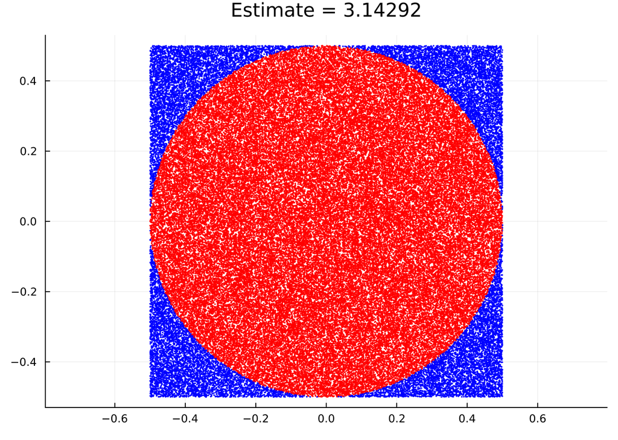

```julia
pi_hat, U, is_inside = @time estimate_pi(0.5, 10^5)
colors = ifelse.(is_inside, "red", "blue")
scatter(U[1,:], U[2,:],
  color = colors,
  markerstrokewidth = 0,
  markersize = 1,
  aspect_ratio = 1,
  title = "Estimate = $(round(pi_hat, digits = 8))"
)
```

## Example: Sampling from a Beta distribution

The [Beta distribution](https://en.wikipedia.org/wiki/Beta_distribution) can be used to model data distributed on finite intervals, such as proportions. Let’s apply our rejection sampling procedure to sample from $\mathrm{Beta}(3, 6)$ using only its PDF.

- We use $U \sim \mathrm{Uniform}(0,1)$ as our proposal.
- The rejection step will also use a standard uniform distribution.
- We can calibrate the envelope $M$ to hug the target distribution as tight as possible.

```julia
function sample_beta(alpha, beta, N; M = 1.0)
  # WARNING: We can't use M = 1 as the default.
  # The best M depends on alpha and beta in general...
  target = Beta(alpha, beta)
  points = zeros(2, N)
  @views rand!(Uniform(0, 1), points[1, :]) # proposal, Y
  @views rand!(Uniform(0, M), points[2, :]) # f(Y) / [M * g(Y)]
  selected = @. points[2, :] < pdf(target, points[1, :])
  deviates = points[1, selected]
  return deviates, points, selected
end
```

```
sample_beta (generic function with 1 method)
```

```
  0.462435 seconds (1.59 M allocations: 84.839 MiB, 98.52% compilation time)
```

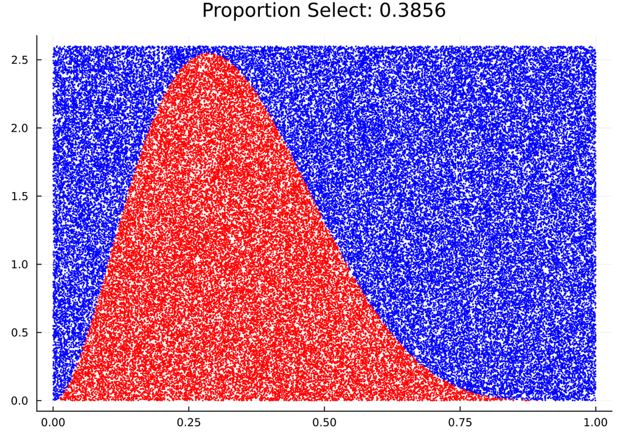

```julia
X, U, selected = @time sample_beta(3.0, 6.0, 10^5; M = 2.6)
colors = ifelse.(selected, "red", "blue")
scatter(U[1,:], U[2,:],
  color = colors,
  markerstrokewidth = 0,
  markersize = 1,
  title = "Proportion Select: $(round(sum(selected) / length(selected), digits = 4))"
)
```

- Try increasing $M$ while keeping the shape parameters $\alpha$ and $\beta$ fixed.
- What happens to the acceptance probability?

## Ziggurat Algorithm (Optional)

The inverse sampling method is easy to implement for distributions, such as the Exponential, which have a closed-form expression for their quantile functions. However, this is not always the fastest method for simulating from such distributions and naive rejection sampling can be inefficient.

The [Ziggurat algorithm](https://en.wikipedia.org/wiki/Ziggurat_algorithm) is a fast rejection method for sampling from distributions that

- have monotonically decreasing PDFs, or
- are unimodal symmetric distributions.

It was developed by [George Marsaglia](https://en.wikipedia.org/wiki/George_Marsaglia) in the 1960s. **The motivation is to minimize the size of a sampler’s rejection region** through a clever covering of a target PDF.

### Geometric intuition

Consider the monotonically decreasing case first, defined on $x \ge 0$. The target PDF is covered by $n$ regions of equal area:

- $n-1$ of these regions are rectangles that cover most of the PDF, starting from the top.
- The first region is a base layer, is a non-rectangular, and covers the tail, which may be infinite.

The construction of these regions proceeds as follows:

- **Base Layer**: Rectangle with $(0, 0)$ and $(x_{1}, y_{1})$ as vertices + tail region where $x \ge x_{1}$ and $y \le y_{1}$. This layer is said to have area $A$.
- **Next Layer**: For layer $i > 1$, add a rectangle of width $x_{i}$ and height $A / x_{i}$; this preserves the area invariant. The top of this layer is at $y_{i+1} = y_{i} + A / x_{i}$ and intersects the PDF at $(x_{i+1}, y_{i+1})$. That is, we define $x_{i+1}$ as the point such that $y_{i+1} = f(x_{i+1})$. Unlike the base layer, these layers include small rejection regions.
- **Initialization**: One needs a procedure to choose the initial width $x_{1}$ such that all $n$ layers have equal area and satisfy $x_{n} = 0$. That is, we need to guarantee that the peak occur at $(0, f(0))$.

See the [Wikipedia animation](https://en.wikipedia.org/wiki/Ziggurat_algorithm#/media/File:Ziggurat_method.gif) to get a sense of this construction. The efficiency of this algorithm is due to the following:

- If each layer has equal area, then we can sample them uniformly.
- If the rejection region of each layer is small, then rejection sampling can be very efficient.

**Note**

The construction of the Ziggurat mimics how [Lebesgue integrals](https://en.wikipedia.org/wiki/Lebesgue_integral) can be computed through the [layer cake representation](https://en.wikipedia.org/wiki/Layer_cake_representation) of a function. That is, one partitions the $y$-axis to cover a function, rather than the $x$-axis as is done for the Reimann integral.

### The algorithm

The basic strategy is as follows:

- Build a lookup table that represents all the layers. This mostly avoids evaluating expensive functions.
- Once we have the table, the rest of the algorithm involves simple sums, standard uniform numbers, and array accesses.
- There are two expensive, but rare exceptions:
  - We sample the base layer and end up in the tail. The memoryless property makes this easy to sample at the cost of a single `-log(U)` call.
  - We sample a non-base layer and end up near the small rejection region. Need to evaluate on `exp(-w)` to check for acceptance/rejection.

```julia
struct ExpZigguratTable
  x::Vector{Float64}
  y::Vector{Float64}
  n::Int
end

function build_layers!(xs, ys, x1)
  m = length(xs)
  xs[1] = x1
  ys[1] = exp(-x1)
  A = (1 + xs[1]) * ys[1] # Area due to base rectangle + tail
  for i in 1:(m-1)
    ynext = ys[i] + A / xs[i]   # Preserve invariant area, A
    ynext >= 1 && return A, Inf # Check for overshooting of peak
    ys[i+1] = ynext
    xs[i+1] = -log(ynext)
  end
  # Compute residual f(xₙ) - 1; should be small
  r = ys[m] + A / xs[m] - 1
  return A, r
end

function ExpZigguratTable(n::Integer = 256)
  # Arrays for representing layers
  x = zeros(Float64, n+1); xs = @view x[2:n]
  y = zeros(Float64, n+1); ys = @view y[2:n]

  # Bisection search to select x₁ such that f(xₙ) - 1 = 0
  lo, hi = 1e-3, 50.0
  A, r = Inf, Inf
  while abs(lo - hi) > 1e-12
    mid = (lo + hi) / 2
    A, r = build_layers!(xs, ys, mid)
    if r > 0   # positive residual: x₁ is too small
      lo = mid
    else       # negative residual: x₁ is too large
      hi = mid
    end
  end

  # Complete the table
  x[1] = 1 + x[2]   # fictitious x₀ = A / f(x₁)
  y[n+1] = 1.0      # yₙ = f(xₙ) = f(0)

  return ExpZigguratTable(x, y, n)
end

function rand_unit_exp(rng::AbstractRNG, table::ExpZigguratTable)
  x, y, n = table.x, table.y, table.n
  while true
    i = rand(rng, 0:n-1)    # Step 1: Choose a random layer
    w = rand(rng) * x[i+1]  # Step 2: x = U₀ × xᵢ
    w < x[i+2] && return w  # Step 3: Check if we're in the acceptance region
    if iszero(i)            # Step 4: Handle the tail using memoryless property
      return x[2] - log(rand(rng))
    end
    # Step 5: We're outside the inner rectangle of the layer.
    # Need to sample a random height on this layer.
    h = y[i+1] + rand(rng) * (y[i+2] - y[i+1])

    # Step 6: Check that we're under the curve (accept).
    h < exp(-w) && return w
  end # Step 7: Back to the start...
end
```

```
rand_unit_exp (generic function with 1 method)
```

Let’s test it for $\mathrm{Exponential}(1)$:

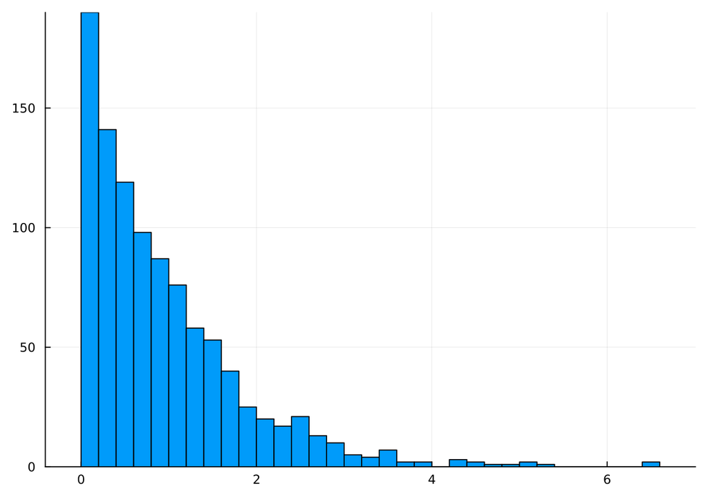

```julia
TABLE = ExpZigguratTable()
rng = Xoshiro(1234)
data = [rand_unit_exp(rng, TABLE) for _ in 1:1000]
histogram(data, bins = 32)
```

**Note**

Our implementation here is not necessarily optimal, yet precomputing expensive quantities is a key ingredient in making the sampler quite fast. This idea is known as [memoization](https://en.wikipedia.org/wiki/Memoization), which trades some storage for savings on expensive function calls.